# Assignment 7: Visualization - Some aspects of ggplot2

- Use `geom_point` to compare the vaccines used by date in Argentina in 2022.

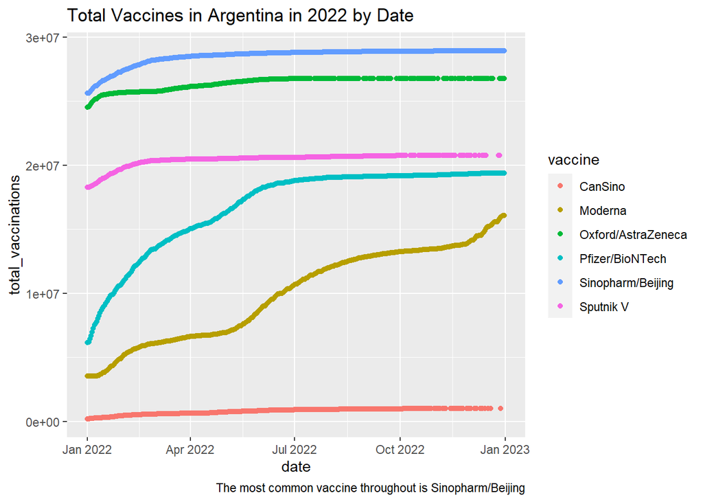

```r
df$year = year(df$date)
df %>%
  filter(location=='Argentina',year==2022) %>%
  ggplot()+
  geom_point(mapping = aes(x = date,
                                    y = total_vaccinations,
                                    color = vaccine)) + labs(
       title = 'Total Vaccines in Argentina in 2022 by Date',
       caption = 'The most common vaccine throughout is Sinopharm/Beijing')
```

- Change `geom_point` to `geom_line` in the above codes to have the corresponding line plots.

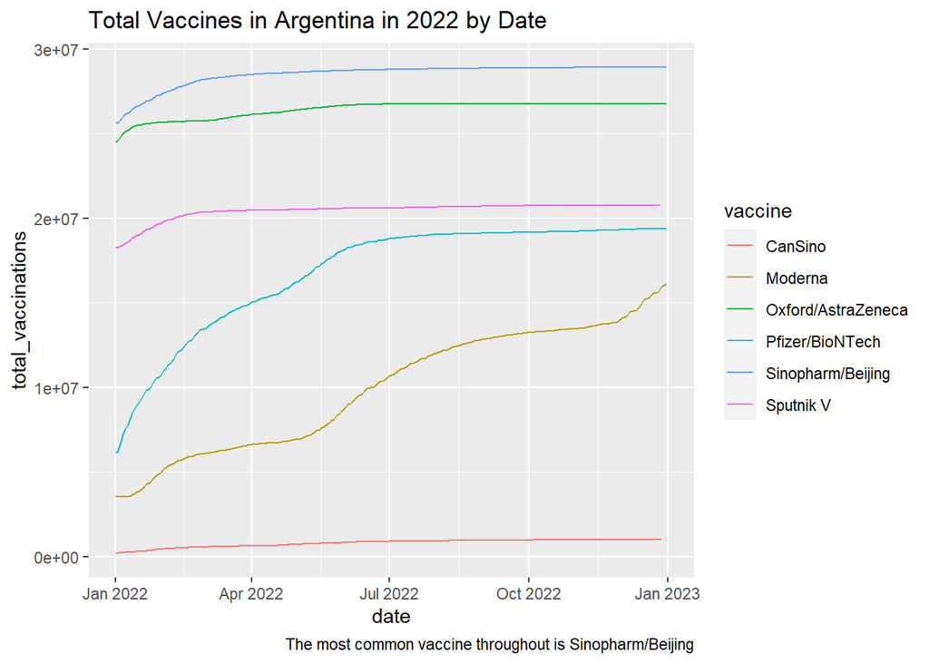

```r
df %>%
  filter(location=='Argentina',year==2022) %>%
  ggplot()+
  geom_line(mapping = aes(x = date,
                                    y = total_vaccinations,
                                    color = vaccine)) + labs(
       title = 'Total Vaccines in Argentina in 2022 by Date',
       caption = 'The most common vaccine throughout is Sinopharm/Beijing')
```

11. (Using the same dataset as in 10.) Sometime we need to do some calculations on the data before plotting. For example, the below codes is to compare the total vaccines (including all types of vaccines) by date between the US and the EU

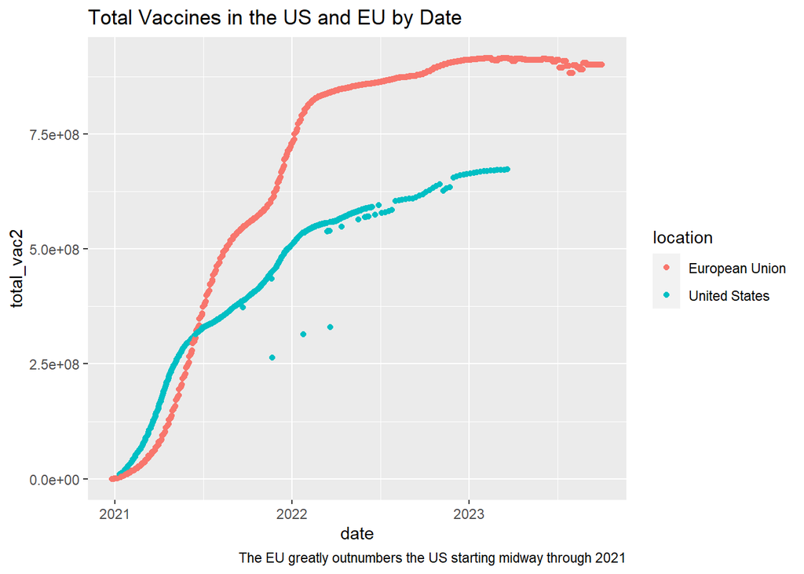

```r
# the total vaccines (including all types of vaccines) by date
d1 <- df %>%
  filter(location %in% c('United States', 'European Union')) %>%
  group_by(date, location) %>%
  summarise(total_vac2=sum(total_vaccinations, na.rm=TRUE))

# Plot
d1 %>%
  ggplot()+
  geom_point(mapping=aes(x=date,
                         y=total_vac2,
                         color=location)) + labs(
       title = 'Total Vaccines in the US and EU by Date',
       caption = 'The EU greatly outnumbers the US starting midway through 2021')
```

Notice that the above codes could be piped in one

```r
df %>%
  filter(location %in% c('United States', 'European Union')) %>%
  group_by(date, location) %>%
  summarise(total_vac2=sum(total_vaccinations, na.rm=TRUE)) %>%
  ggplot()+
  geom_point(mapping=aes(x=date,
                         y=total_vac2,
                         color=location))+ labs(
       title = 'Total Vaccines in the US and EU by Date',
       caption = 'The EU greatly outnumbers the US starting midway through 2021')
```

[output not shown]

Do the follows.

- Use `geom_point` compare the total vaccines (including all types of vaccines) by date between countries/regions in Asia

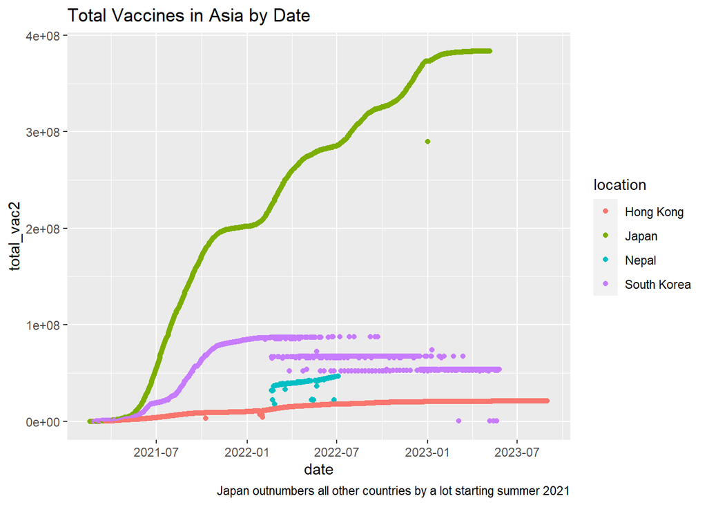

```r
df %>%
  filter(location %in% c('Hong Kong', 'Japan','South Korea','Nepal')) %>%
  group_by(date, location) %>%
  summarise(total_vac2=sum(total_vaccinations, na.rm=TRUE)) %>%
  ggplot()+
  geom_point(mapping=aes(x=date,
                         y=total_vac2,
                         color=location)) + labs(
       title = 'Total Vaccines in Asia by Date',
       caption = 'Japan outnumbers all other countries by a lot starting summer 2021')
```

- Use `geom_point` compare the total vaccines (including all types of vaccines) by date between countries/regions in South America in 2021

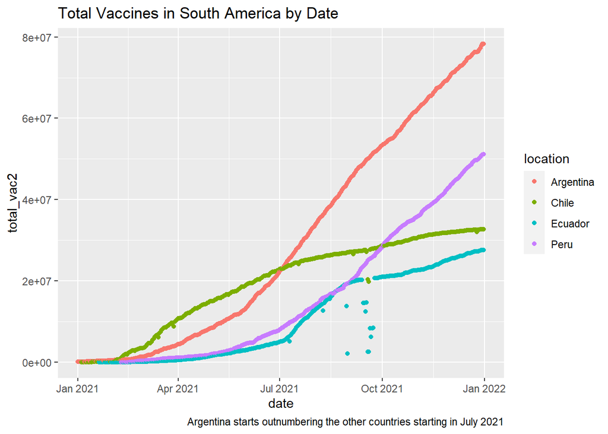

```r
df %>%
  filter(location %in% c('Argentina', 'Chile','Ecuador','Peru'), year==2021) %>%
  group_by(date, location) %>%
  summarise(total_vac2=sum(total_vaccinations, na.rm=TRUE)) %>%
  ggplot()+
  geom_point(mapping=aes(x=date,
                         y=total_vac2,
                         color=location)) + labs(
       title = 'Total Vaccines in South America by Date',
       caption = 'Argentina starts outnumbering the other countries starting in July 2021')
```